# Исследование объявлений о продаже квартир

В вашем распоряжении данные сервиса Яндекс.Недвижимость — архив объявлений о продаже квартир в Санкт-Петербурге и соседних населённых пунктах за несколько лет. Нужно научиться определять рыночную стоимость объектов недвижимости. Ваша задача — установить параметры. Это позволит построить автоматизированную систему: она отследит аномалии и мошенническую деятельность.

По каждой квартире на продажу доступны два вида данных. Первые вписаны пользователем, вторые — получены автоматически на основе картографических данных. Например, расстояние до центра, аэропорта, ближайшего парка и водоёма.

### Шаг 1. Открыть файл с данными и изучить общую информацию.

### Вывод

Файл содержит данные по 23699 объектам недвижимости, каждый из которых описывается 22 признаками (17 количественных, 4 категориальных и 1 временной). У некоторых признаков есть пропущенные значения, которые необходимо обработать.

Ход исследования:

```python
import pandas as pd
import seaborn as sns
import numpy as np
import matplotlib.pyplot as plt
data = pd.read_csv('/datasets/real_estate_data.csv', sep='\t')
pd.set_option('display.max_columns', 500)
data.head()
```

|  | total_images | last_price | total_area | first_day_exposition | rooms | ceiling_height | floors_total | living_area | floor | is_apartment | studio | open_plan | kitchen_area | balcony | locality_name | airports_nearest | cityCenters_nearest | parks_around3000 | parks_nearest | ponds_around3000 | ponds_nearest | days_exposition |
| --- | --- | --- | --- | --- | --- | --- | --- | --- | --- | --- | --- | --- | --- | --- | --- | --- | --- | --- | --- | --- | --- | --- |
| 0 | 20 | 13000000.0 | 108.0 | 2019-03-07T00:00:00 | 3 | 2.70 | 16.0 | 51.0 | 8 | NaN | False | False | 25.0 | NaN | Санкт-Петербург | 18863.0 | 16028.0 | 1.0 | 482.0 | 2.0 | 755.0 | NaN |
| 1 | 7 | 3350000.0 | 40.4 | 2018-12-04T00:00:00 | 1 | NaN | 11.0 | 18.6 | 1 | NaN | False | False | 11.0 | 2.0 | посёлок Шушары | 12817.0 | 18603.0 | 0.0 | NaN | 0.0 | NaN | 81.0 |
| 2 | 10 | 5196000.0 | 56.0 | 2015-08-20T00:00:00 | 2 | NaN | 5.0 | 34.3 | 4 | NaN | False | False | 8.3 | 0.0 | Санкт-Петербург | 21741.0 | 13933.0 | 1.0 | 90.0 | 2.0 | 574.0 | 558.0 |
| 3 | 0 | 64900000.0 | 159.0 | 2015-07-24T00:00:00 | 3 | NaN | 14.0 | NaN | 9 | NaN | False | False | NaN | 0.0 | Санкт-Петербург | 28098.0 | 6800.0 | 2.0 | 84.0 | 3.0 | 234.0 | 424.0 |
| 4 | 2 | 10000000.0 | 100.0 | 2018-06-19T00:00:00 | 2 | 3.03 | 14.0 | 32.0 | 13 | NaN | False | False | 41.0 | NaN | Санкт-Петербург | 31856.0 | 8098.0 | 2.0 | 112.0 | 1.0 | 48.0 | 121.0 |

```python
data.info()
```

```
<class 'pandas.core.frame.DataFrame'>
RangeIndex: 23699 entries, 0 to 23698
Data columns (total 22 columns):
total_images            23699 non-null int64
last_price              23699 non-null float64
total_area              23699 non-null float64
first_day_exposition    23699 non-null object
rooms                   23699 non-null int64
ceiling_height          14504 non-null float64
floors_total            23613 non-null float64
living_area             21796 non-null float64
floor                   23699 non-null int64
is_apartment            2775 non-null object
studio                  23699 non-null bool
open_plan               23699 non-null bool
kitchen_area            21421 non-null float64
balcony                 12180 non-null float64
locality_name           23650 non-null object
airports_nearest        18157 non-null float64
cityCenters_nearest     18180 non-null float64
parks_around3000        18181 non-null float64
parks_nearest           8079 non-null float64
ponds_around3000        18181 non-null float64
ponds_nearest           9110 non-null float64
days_exposition         20518 non-null float64
dtypes: bool(2), float64(14), int64(3), object(3)
memory usage: 3.7+ MB
```

### Шаг 2. Предобработка данных

### Вывод

**1. Пропущенные значения**

- **Высота потолков**: было пропущено 38,8% значений, при этом часть значений были введены вручную с ошибкой (27 м вместо 2,7 м и т.д.). Необходимо добавить условие на ручной ввод: высота потолков не может быть двузначной величиной, а также меньше 2,5 м (в данных существуют значения в 1,75 м и даже в 1 м). Все пропущенные значения обработаны: была сделана замена на медиану для зданий конкретной этажности (либо на общую медиану).
- **Число этажей в доме**: пропущено 0,4% значений. Данный признак будет использоваться в анализе, при этом достаточно точно заменить пропущенные значения не представляется возможным, поэтому все строки с пропущенными значениями удалены. Предлагается автоматизировать заполнение данных по этому признаку для городов на основе точного адреса.
- **Жилая площадь** и **площадь кухни**: пропущено 7,9% и 9,4% значений соответственно. Была построена зависимость на основе гипотезы, что если нам известна общая площадь недвижимости, то мы можем оценить, сколько квадратных метров составляет жилая площадь и площадь кухни на основе уже заполненных пользователями данных.
- **Число балконов**: пропущено 48,6% значений. Предполагается, что отсутствие числа балконов свидетельствует о том, что число балконов равно нулю.
- **Название населенного пункта**: пропущено 0,2% значений. Все строки с пропущенными значениями удалены, так как этот признак будет использоваться при дальнейшем анализе. Необходимо ввести условие об обязательном заполнении данного признака в объявлении (либо об автоматизированном заполнении на основе указанной улицы, если это возможно).
- **Расстояние до центра города**: пропущено 23,3% значений. При этом из всех квартир Санкт-Петербурга отсутствует информация по расстоянию до центра для **0,4% квартир**. Поскольку трудоемкость заполнения таких пропущенных значений велика по сравнению с их общим количеством, оставим данные пропущенные значения без изменений.
- **Апартаменты, расстояние до ближайшего аэропорта, число парков в радиусе 3 км, расстояние до ближайшего парка, число водоемов в радиусе 3 км, расстояние до ближайшего водоема**: пропущенные значения в этих признаках оставлены без изменений, так как они не будут использованы в текущем исследовании.
- **Длительность размещения объявления**: пропущено 13,5% значений. Все пропущенные значения были заменены на медиану.

**2. Замена типа данных**

Тип признака **Время публикации объявления** был заменен со строчного на временной.

Ход исследования:

#### 1. Пропущенные значения

```python
# функция, получающая на вход название признака, и возвращающая число пропущенных значений
def print_nan_ratio(column):
    return print('Пропущено {:.1%}'. format(data[column].isna().value_counts()[1] / len(data), 2) + ' значений')
```

**1.1** Высота потолков

```python
print_nan_ratio('ceiling_height')
ceiling_medians = data.pivot_table(index='floors_total', values='ceiling_height', aggfunc=['median', 'count'])
ceiling_medians.columns = ['median', 'count']
ceiling_medians.head()
```

```
Пропущено 38.8% значений
```

| floors_total | median | count |
| --- | --- | --- |
| 1.0 | 2.80 | 10 |
| 2.0 | 2.70 | 215 |
| 3.0 | 2.80 | 399 |
| 4.0 | 3.00 | 789 |
| 5.0 | 2.55 | 3666 |

```python
# заменяем значения высоты потолков на общую медиану для отсутствующих значений этажности дома
for floor in ceiling_medians.index:
    data.loc[(data['floors_total'].isna()) |
             ((data['floors_total'] == floor) & (ceiling_medians.loc[floor, 'count'] == 0)),
             'ceiling_height'] = data['ceiling_height'].describe()[5]

# медианы из сгруппированной таблицы вставляем на места пропущенных значений высоты потолков для дома соответствующей этажности
for floor in ceiling_medians.index:
    data.loc[(data['ceiling_height'].isna()) &
             (data['floors_total'] == floor),
             'ceiling_height'] = ceiling_medians.loc[floor, 'median']

# посчитаем количество пропущенных значений после проделанной замены
data['ceiling_height'].isna().value_counts()
```

```
False    23699
Name: ceiling_height, dtype: int64
```

**1.2** Число этажей в доме

```python
print_nan_ratio('floors_total')
data.dropna(subset=['floors_total'], inplace=True)
```

```
Пропущено 0.4% значений
```

**1.3** Жилая площадь

Оценим зависимость жилой площади от общей площади недвижимости с помощью линейной регрессии.

Минимизируем квадратичную функцию ошибки:

$$error(w_0, w_1) = \sum_{i=1}^n {(y_i - (w_0 + w_1 * x_i))}^2 $$

Здесь $n$ – число наблюдений в наборе данных *'living_area_notna'*, $y_i$ и $x_i$ – жилая и общая площадь $i$-ого объекта недвижимости в наборе данных.

```
Пропущено 7.9% значений
```

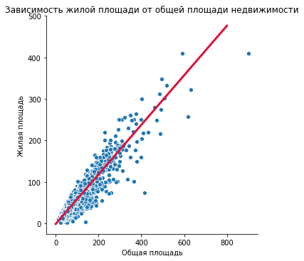

```python
print_nan_ratio('living_area')

from scipy.optimize import minimize

# сначала очистим данные от пропущенных значений
living_area_notna = data.query('living_area.notna()').reset_index(drop=True)

# зададим квадратичную функцию ошибки, зависящую от вектора параметров
def error_function(w):
    sum = 0
    for i in range(len(living_area_notna)):
        sum += (living_area_notna.loc[i, 'living_area'] - (w[0] + w[1] * living_area_notna.loc[i, 'total_area'])) ** 2
    return sum

# решим задачу минимизации заданной функции с некоторым начальным приближением
result = minimize(error_function, np.array([0, 0]))

# зададим линейную функцию, отображающую наше решение
def linear_function(w0, w1, x):
    return (w0 + w1 * x)

# Изобразим решение на графике
sns.relplot(x='total_area', y='living_area', data=data)

total_area = np.linspace(0, 800)
line = plt.plot(total_area, linear_function(result.x[0], result.x[1], total_area), color='crimson', linewidth=3)
plt.title('Зависимость жилой площади от общей площади недвижимости')
plt.xlabel('Общая площадь')
plt.ylabel('Жилая площадь')
plt.show()
```

```python
# заменим все пропущенные значения на основе оцененной зависимости
data.loc[data['living_area'].isna(),
         'living_area'] = result.x[0] + result.x[1] * data.loc[data['living_area'].isna(), 'total_area']

# проверим, все ли пропущенные значения мы обработали
data['living_area'].isna().value_counts()
```

```
False    23613
Name: living_area, dtype: int64
```

**1.4** Площадь кухни

```
Пропущено 9.4% значений
```

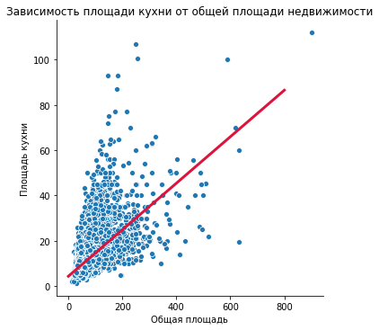

```python
# вычислим долю пропущенных значений
print_nan_ratio('kitchen_area')

# сначала очистим данные от пропущенных значений
kitchen_area_notna = data.query('kitchen_area.notna()').reset_index(drop=True)

# зададим квадратичную функцию ошибки, зависящую от вектора параметров
def error_function(w):
    sum = 0
    for i in range(len(kitchen_area_notna)):
        sum += (kitchen_area_notna.loc[i, 'kitchen_area'] - (w[0] + w[1] * kitchen_area_notna.loc[i, 'total_area'])) ** 2
    return sum

# решим задачу минимизации заданной функции с некоторым начальным приближением
result = minimize(error_function, np.array([0, 0]))

# Изобразим решение на графике
sns.relplot(x='total_area', y='kitchen_area', data=data)

total_area = np.linspace(0, 800)
line = plt.plot(total_area, linear_function(result.x[0], result.x[1], total_area), color='crimson', linewidth=3)
plt.title('Зависимость площади кухни от общей площади недвижимости')
plt.xlabel('Общая площадь')
plt.ylabel('Площадь кухни')
plt.show()
```

```python
# заменим пропущенные значения площади кухнина в квартирах-студиях на нули
data.loc[data['studio'] == True, 'kitchen_area'] = 0

# заполним пропущенные значения для квартир, которые не являются студиями
data.loc[data['kitchen_area'].isna(),
         'kitchen_area'] = result.x[0] + result.x[1] * data.loc[data['kitchen_area'].isna(), 'total_area']

# проверим, все ли пропущенные значения мы обработали
data['kitchen_area'].isna().value_counts()
```

```
False    23613
Name: kitchen_area, dtype: int64
```

**1.5** Число балконов

```python
print_nan_ratio('balcony')
```

```
Пропущено 48.6% значений
```

```python
data['balcony'].fillna(0, inplace=True)
data['balcony'].isna().value_counts()
```

```
False    23613
Name: balcony, dtype: int64
```

**1.6** Название населенного пункта

```python
print_nan_ratio('locality_name')
data.dropna(subset=['locality_name'], inplace=True)
```

```
Пропущено 0.2% значений
```

**1.7** Расстояние до центра города

```python
print_nan_ratio('cityCenters_nearest')
```

```
Пропущено 23.3% значений
```

Выясним, сколько пропущено значений расстояния до центра для квартир из Санкт-Петербурга. Эти данные впоследствии понадобятся для анализа.

```python
round(len(data[(data['locality_name'] == 'Санкт-Петербург') & (data['cityCenters_nearest'].isna())]) / len(data.reset_index(drop=True).query('locality_name == "Санкт-Петербург"')), 3)
```

```
0.004
```

**1.8** Апартаменты

```python
print_nan_ratio('is_apartment')
```

```
Пропущено 88.3% значений
```

**1.9** Расстояние до ближайшего аэропорта

```python
print_nan_ratio('airports_nearest')
```

```
Пропущено 23.4% значений
```

**1.10** Число парков в радиусе 3 км

```python
print_nan_ratio('parks_around3000')
```

```
Пропущено 23.3% значений
```

**1.11** Расстояние до ближайшего парка

```python
print_nan_ratio('parks_nearest')
```

```
Пропущено 65.9% значений
```

**1.12** Число водоемов в радиусе 3 км

```python
print_nan_ratio('ponds_around3000')
```

```
Пропущено 23.3% значений
```

**1.13** Расстояние до ближайшего водоема

```python
print_nan_ratio('ponds_nearest')
```

```
Пропущено 61.7% значений
```

**1.14** Длительность размещения объявления (от публикации до снятия)

```python
print_nan_ratio('days_exposition')
```

```
Пропущено 13.5% значений
```

```python
# заменим пропуски на медианные значения
data.loc[data['days_exposition'].isna(), 'days_exposition'] = data['days_exposition'].describe()[5]
```

#### 2. Замена типа данных

```python
# заменим тип данных по дате публикации со строчного на datetime
data['first_day_exposition'] = pd.to_datetime(data['first_day_exposition'], format='%Y-%m-%dT%H:%M:%S')
```

### Шаг 3. Посчитайте и добавьте в таблицу

#### Цена квадратного метра:

```python
data['price_per_sqm'] = round(data['last_price'] / data['total_area'], 1)
```

#### День недели, месяц и год публикации объявления:

```python
data['weekday'] = data['first_day_exposition'].dt.weekday
data['month'] = data['first_day_exposition'].dt.month
data['year'] = data['first_day_exposition'].dt.year
```

#### Этаж квартиры (первый, последний, другой):

```python
data.loc[data['floor'] == 1, 'floor_category'] = 'первый'
data.loc[data['floor'] == data['floors_total'], 'floor_category'] = 'последний'
data.loc[data['floor_category'].isna(), 'floor_category'] = 'другой'
```

#### Соотношение жилой и общей площади, а также отношение площади кухни к общей:

```python
data['living_area_ratio'] = round(data['living_area'] / data['total_area'], 3)
data['kitchen_area_ratio'] = round(data['kitchen_area'] / data['total_area'], 3)
```

### Шаг 4. Проведите исследовательский анализ данных и выполните инструкции:

**I. Исследование параметров объектов из Санкт-Петербурга и соседних населенных пунктов.**

#### Вывод

**1. Изучение параметров: площади, цены, числа комнат, высоты потолков, срока продажи квартиры**

*Средняя квартира*, выставленная на продажу, имеет следующие характеристики: это *2-комнатная* квартира площадью *52 кв. м* с потолками *2,65 м*, проданная *за 3 месяца (95 дней)* по цене *4,7 млн рублей*.

*Аномальные характеристики* квартир из представленного набора данных:

- *7-комнатная* квартира или больше
- площадью более *114,3 кв. м*
- с потолками менее *2,25 м* или более *3,05 м*
- по цене более *11,9 млн рублей*
- проданная *за 14 месяцев (428 дней)* или более

**Срок продажи квартиры**. Как правило, продажа недвижимости занимала **3 месяца (95 дней)**. При этом четверть всех объектов недвижимости была продана в течение 45 дней с момента публикации. Если объект был продан **в течение месяца**, то необходимо проверить данную сделку на предмет мошенничества. Такая проверка особенна критична, если срок сделки не превышает **двух недель**. Кроме того, если объект был продан только после **14 месяцев** (428 дней) с момента публикации, это говорит об аномально долгой продаже.

**2. Факторы, влияющие на стоимость квартиры**

- Тривиально, наиболее сильная корреляция наблюдается между площадью квартиры и ее стоимостью (*коэфф. корреляции 0,68*).
- Расстояние до центра города также, очевидно, влияет на стоимость квартиры, но обратно пропорционально и не так сильно (*коэфф. корреляции -0,31*).
- Стоимость квартиры также напрямую зависит от числа комнат: чем их больше, тем квартира дороже. Но это верно, пока число комнат не превышает четырех: 5- или 6-комнатные квартиры могут быть проданы дешевле 4-комнатных, и вызвано это скорее всего отсутствием спроса.
- Квартиры на первом или последнем этаже обычно продаются по более низкой цене, чем квартиры на других этажах.
- День недели и месяц публикации объявления не играют значимой роли на стоимость, по которой объект недвижимости будет продан. Исследование лишь показало, что в среднем квартиры продавались по более высоким ценам в 2014 году, но это объясняется макроэкономической ситуацией и переходом ЦБ РФ к плавающему курсу в конце 2014 года.

**3. 10 населенных пунктов с наибольшим числом объявлений**

Из представленных 10 населенных пунктов с наибольшим числом объявлений **лидеры по средней цене квадратного метра: Санкт-Петербург, Пушкин, деревня Кудрово и поселок Парголово**.

Однако в среднем **дешевле всего** квадратные метры **в Выборге и Всеволожске**.

Результаты вызывают вопросы: цена квадратного метра в деревне больше, чем в городе. Необходимо будет установить, насколько такая разница в средней цене квадратного метра обоснована и вызвана близостью к центру Санкт-Петербурга.

Ход исследования:

На данном этапе необходимо избавиться от выбросов: сейчас диаграммы (вроде *sns.pairplot*) не помогут сделать хоть сколько-нибудь значимые выводы. Рассмотрим подробнее каждый признак.

Создадим функцию, определяющую границы "усов" для задаваемого признака.

```python
# функция, получающая на вход название признака, и возвращающая границы "усов"
def det_whiskers(column):
    stat = data[column].describe()

    # межквартирльный размах
    iqr = stat[6] - stat[4]

    # левый и правый "ус"
    left_whisker = round(stat[4] - 1.5 * iqr, 2)
    right_whisker = round(stat[6] + 1.5 * iqr, 2)

    # левый "ус" не должен быть меньше минимального значения
    if left_whisker < stat[3]: left_whisker = stat[3]

    # правый "ус" не должен быть больше максимального значения
    if right_whisker > stat[7]: right_whisker = stat[7]

    return [left_whisker, right_whisker]
```

**1.1**. Площадь

```python
det_whiskers('total_area')
```

```
[12.0, 114.25]
```

```python
data['total_area'].describe()
```

```
count    23565.000000
mean        60.322824
std         35.657060
min         12.000000
25%         40.000000
50%         52.000000
75%         69.700000
max        900.000000
Name: total_area, dtype: float64
```

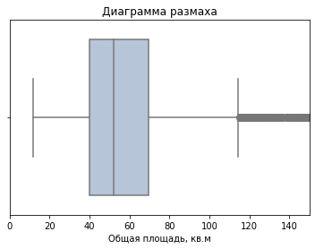

```python
# построим диаграмму размаха, ограничив площадь 150 кв.м
sns.boxplot(data['total_area'], color='lightsteelblue')
plt.title('Диаграмма размаха')
plt.xlabel('Общая площадь, кв.м')
plt.xlim(0, 150)
plt.show()
```

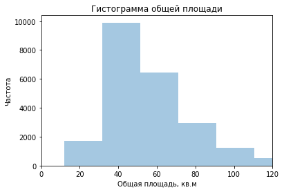

```python
# Построим диаграмму для объектов с площадью менее 120 кв.м.
sns.distplot(data['total_area'], kde=False, bins=45)
plt.xlim(0, 120)
plt.title('Гистограмма общей площади')
plt.xlabel('Общая площадь, кв.м')
plt.ylabel('Частота')
plt.show()
```

```python
# зададим функцию, вычисляющую долю аномальных значений
def print_anomalies_ratio(column):
    return 'Аномальные значения составляют {:.1%}'. format(len(data.loc[data[column] > det_whiskers(column)[1]]) / len(data)) + ' от всей выборки'
print_anomalies_ratio('total_area')
```

```
'Аномальные значения составляют 5.3% от всей выборки'
```

Добавим столбец с признаком, описывающим аномально большую площадь недвижимости.

```python
data['too_large_area'] = data['total_area'] > det_whiskers('total_area')[1]
```

**1.2**. Цена

```python
det_whiskers('last_price')
```

```
[12190.0, 11875000.0]
```

```python
data['last_price'].describe()
```

```
count    2.356500e+04
mean     6.540058e+06
std      1.091093e+07
min      1.219000e+04
25%      3.400000e+06
50%      4.646000e+06
75%      6.790000e+06
max      7.630000e+08
Name: last_price, dtype: float64
```

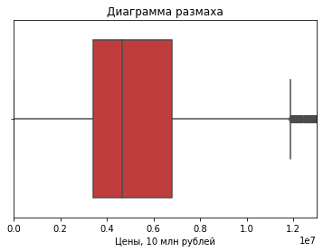

```python
sns.boxplot(data['last_price'], color='tab:red')
plt.title('Диаграмма размаха')
plt.xlabel('Цены, 10 млн рублей')
_ = plt.xlim(0, 13000000)
```

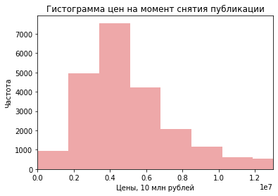

```python
sns.distplot(data['last_price'], kde=False, bins=450, color='tab:red')
plt.xlim(0, 13000000)
plt.title('Гистограмма цен на момент снятия публикации')
plt.xlabel('Цены, 10 млн рублей')
_ = plt.ylabel('Частота')
```

```python
print_anomalies_ratio('last_price')
```

```
'Аномальные значения составляют 8.7% от всей выборки'
```

Добавим столбец с признаком, описывающим аномально дорогую недвижимость.

```python
data['too_expensive'] = data['last_price'] > det_whiskers('last_price')[1]
```

**1.3**. Число комнат

```python
det_whiskers('rooms')
```

```
[0.0, 6.0]
```

```python
data['rooms'].describe()
```

```
count    23565.000000
mean         2.070656
std          1.078591
min          0.000000
25%          1.000000
50%          2.000000
75%          3.000000
max         19.000000
Name: rooms, dtype: float64
```

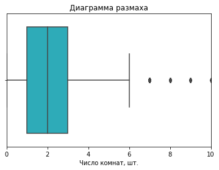

```python
sns.boxplot(data['rooms'], color='tab:cyan')
plt.title('Диаграмма размаха')
plt.xlabel('Число комнат, шт.')
_ = plt.xlim(0, 10)
```

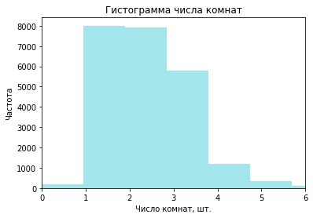

```python
sns.distplot(data['rooms'], kde=False, bins=20, color='tab:cyan')
plt.xlim(0, 6)
plt.title('Гистограмма числа комнат')
plt.xlabel('Число комнат, шт.')
_ = plt.ylabel('Частота')
```

```python
print_anomalies_ratio('rooms')
```

```
'Аномальные значения составляют 0.4% от всей выборки'
```

Добавим столбец с признаком, описывающим недвижимость с аномально большим числом комнат.

```python
data['too_many_rooms'] = data['rooms'] > det_whiskers('rooms')[1]
```

**1.4**. Высота потолков

```python
det_whiskers('ceiling_height')
```

```
[2.25, 3.05]
```

```python
data['ceiling_height'].describe()
```

```
count    23565.000000
mean         2.735737
std          0.996999
min          1.000000
25%          2.550000
50%          2.650000
75%          2.750000
max        100.000000
Name: ceiling_height, dtype: float64
```

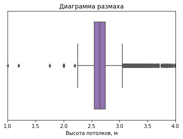

```python
sns.boxplot(data['ceiling_height'], color='tab:purple')
plt.title('Диаграмма размаха')
plt.xlabel('Высота потолков, м')
_ = plt.xlim(1, 4)
```

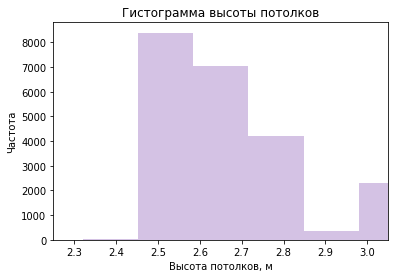

```python
sns.distplot(data['ceiling_height'], kde=False, bins=750, color='tab:purple')
plt.xlim(det_whiskers('ceiling_height')[0], det_whiskers('ceiling_height')[1])
plt.title('Гистограмма высоты потолков')
plt.xlabel('Высота потолков, м')
_ = plt.ylabel('Частота')
```

```python
print_anomalies_ratio('ceiling_height')
```

```
'Аномальные значения составляют 6.2% от всей выборки'
```

```python
data['unusual_ceiling'] = (data['ceiling_height'] > det_whiskers('ceiling_height')[1]) | (data['ceiling_height'] < det_whiskers('ceiling_height')[0])
```

**1.5**. Срок продажи квартиры

```python
det_whiskers('days_exposition')
```

```
[1.0, 427.5]
```

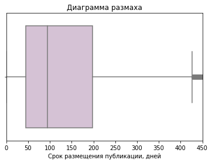

```python
sns.boxplot(data['days_exposition'], color='thistle')
plt.title('Диаграмма размаха')
plt.xlabel('Срок размещения публикации, дней')
_ = plt.xlim(0, 450)
```

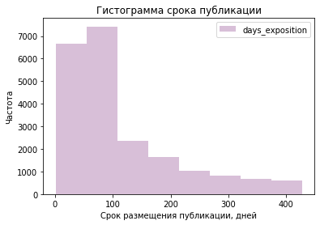

```python
data.plot(y='days_exposition',
          kind='hist',
          color='thistle',
          range=(det_whiskers('days_exposition')[0], det_whiskers('days_exposition')[1]),
          bins=8)
plt.title('Гистограмма срока публикации')
plt.xlabel('Срок размещения публикации, дней')
_ = plt.ylabel('Частота')
```

```python
data['days_exposition'].describe()
```

```
count    23565.000000
mean       169.203692
std        206.497729
min          1.000000
25%         45.000000
50%         95.000000
75%        198.000000
max       1580.000000
Name: days_exposition, dtype: float64
```

```python
data['too_slow'] = data['days_exposition'] > det_whiskers('days_exposition')[1]
data['too_fast'] = data['days_exposition'] < 30
```

**1.6**. Уберем редкие и выбивающиеся значения

```python
good_data = data[(data['too_large_area'] == False) &
     (data['too_expensive'] == False) &
     (data['too_many_rooms'] == False) &
     (data['unusual_ceiling'] == False) &
     (data['too_slow'] == False) &
     (data['too_fast'] == False)].reset_index(drop=True)

print('Доля чистых значений составила: {:.1%}'. format(len(good_data) / len(data)))
```

```
Доля чистых значений составила: 65.3%
```

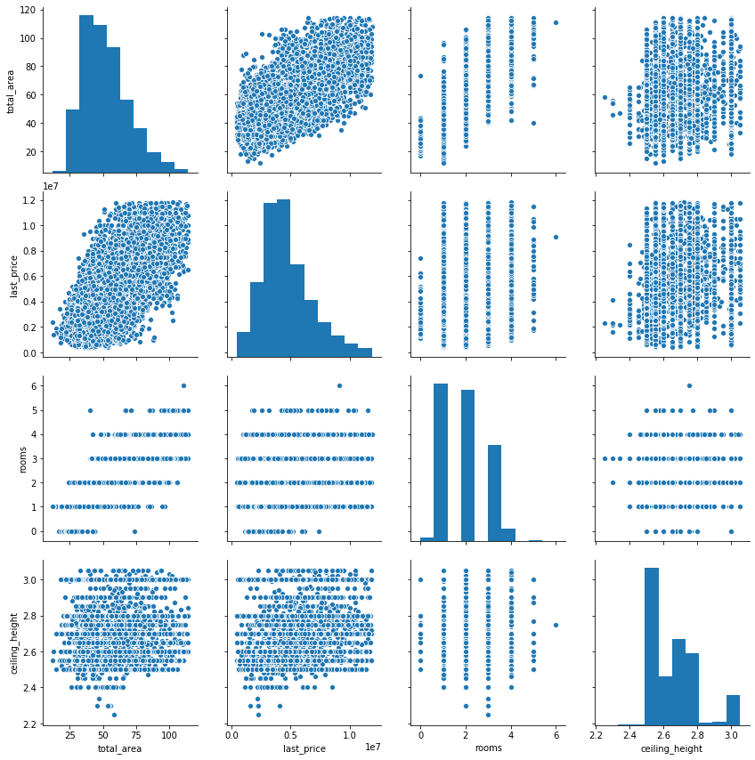

```python
_ = sns.pairplot(good_data,
                 vars=['total_area', 'last_price', 'rooms', 'ceiling_height'],
                 height=3)
```

#### 2. Факторы, влияющие на стоимость квартиры

**2.1** Зависимость цены от площади квартиры и от расстояния до центра города

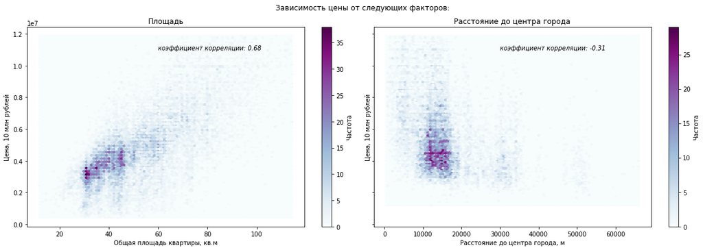

```python
fig, [ax1, ax2] = plt.subplots(1, 2, sharey=True, figsize=(17, 6), gridspec_kw={'wspace': 0})
fig.suptitle('Зависимость цены от следующих факторов:')

# построим график зависимости цены от площади
ax1.set_title('Площадь')
ax1.set_ylabel('Цена, 10 млн рублей')
ax1.set_xlabel('Общая площадь квартиры, кв.м')
ax1.text(60, 11000000,
         'коэффициент корреляции: ' + str(round(good_data['last_price'].corr(good_data['total_area']), 2)),
         style='italic')
hb1 = ax1.hexbin(good_data['total_area'], good_data['last_price'], cmap='BuPu')
cb1 = fig.colorbar(hb1, ax=ax1)
cb1.set_label('Частота')

# построим график зависимости цены от расстояния до центра города
ax2.set_title('Расстояние до центра города')
ax2.set_ylabel('Цена, 10 млн рублей')
ax2.set_xlabel('Расстояние до центра города, м')
ax2.text(30000, 11000000,
         'коэффициент корреляции: ' + str(round(good_data['last_price'].corr(good_data['cityCenters_nearest']), 2)),
         style='italic')
hb2 = ax2.hexbin(good_data['cityCenters_nearest'], good_data['last_price'], cmap='BuPu')
cb2 = fig.colorbar(hb2, ax=ax2)
cb2.set_label('Частота')

plt.tight_layout(pad=3)
plt.show()
```

**2.2** Зависимость цены от числа комнат, этажа квартиры и времени публикации объявления

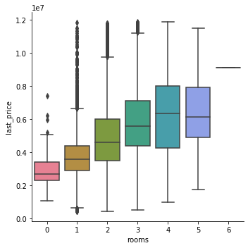

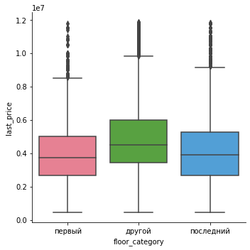

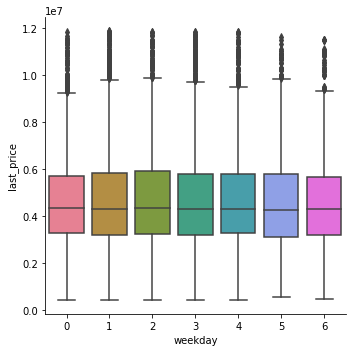

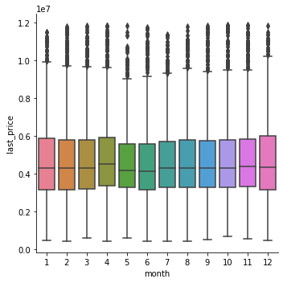

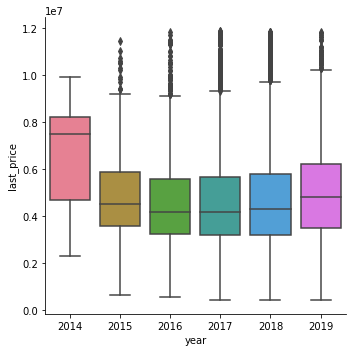

```python
for column in ['rooms', 'floor_category', 'weekday', 'month', 'year']:
    sns.catplot(x=column, y="last_price", kind="box", data=good_data, palette='husl')
```

**3. 10 населенных пунктов с наибольшим числом объявлений**

```python
median_price_per_sqm = good_data.pivot_table(index='locality_name', values='price_per_sqm', aggfunc=['count', 'median'])
median_price_per_sqm.columns = ['count', 'median']
median_price_per_sqm.sort_values('count', ascending=False).head(10)
```

| locality_name | count | median |
| --- | --- | --- |
| Санкт-Петербург | 9392 | 102146.70 |
| посёлок Мурино | 364 | 85714.30 |
| посёлок Шушары | 337 | 76584.50 |
| Всеволожск | 313 | 65853.70 |
| Пушкин | 250 | 98454.75 |
| посёлок Парголово | 248 | 91145.25 |
| Колпино | 237 | 74324.30 |
| Гатчина | 228 | 67417.30 |
| деревня Кудрово | 212 | 92225.05 |
| Выборг | 174 | 57392.65 |

**II. Исследование параметров объектов из центра Санкт-Петербурга.**

#### Вывод

**1. Изучение параметров: площади, цены, числа комнат, высоты потолков**

*Средняя квартира*, выставленная на продажу в центре Санкт-Петербурга, имеет следующие характеристики: это *2-комнатная* квартира площадью *60 кв. м* с потолками *2,75 м*, проданная *за 3 месяца (95 дней)* по цене *6,9 млн рублей*.

**2. Факторы, влияющие на стоимость квартиры**

- Зависимость стоимости квартиры от **числа комнат** в центре Санкт-Петербурга сильнее: здесь больше платежеспособного спроса на 5-комнатные квартиры, что приводит к прямо пропорциональной зависимости цены от числа комнат. Другими словами, 5-комнатные квартиры в центре Санкт-Петербурга, как правило, будут продаваться дороже, чем 4-комнатные.
- Кроме того, в центре города наблюдается явно выраженная зависимость от **этажа квартиры**: квартира на последнем этаже в среднем будет стоить дороже, чем на первом. Это не наблюдается в явном виде в окрестностях центра.
- **Чем дальше от центра города**, тем в среднем квартира будет стоить дешевле: в среднем разница в стоимости между первым и восьмым километром от центра может достигать 2 млн руб.
- Странным образом квартиры, объявления о продаже которых публиковались **по воскресеньям**, продавались в среднем по более высокой цене. То же верно и для объявлений, опубликованных в начале весны и начале осени (**в марте и сентябре** соответственно) в период 2015-2019 гг.: в среднем такие квартиры продавались дороже.

Ход исследования:

**Выделение центра Санкт-Петербурга**

```python
data['citycenters_km'] = round(data['cityCenters_nearest'] / 1000, 0)
data['citycenters_km'] = data['citycenters_km'].astype('int', errors='ignore')
good_data = data[(data['too_large_area'] == False) &
     (data['too_expensive'] == False) &
     (data['too_many_rooms'] == False) &
     (data['unusual_ceiling'] == False) &
     (data['too_slow'] == False) &
     (data['too_fast'] == False)].reset_index(drop=True)

good_data.loc[(good_data['locality_name'] == 'Санкт-Петербург') & (good_data['citycenters_km'].notna()), 'citycenters_km'].apply(round)
spb_data = good_data.query('locality_name == "Санкт-Петербург"')
spb_center_nearest = spb_data.pivot_table(index='citycenters_km', values=['price_per_sqm', 'last_price'], aggfunc='median')
spb_center_nearest.head()
```

| citycenters_km | last_price | price_per_sqm |
| --- | --- | --- |
| 0.0 | 6100000.0 | 126560.65 |
| 1.0 | 7750000.0 | 110178.25 |
| 2.0 | 7950000.0 | 112195.10 |
| 3.0 | 7370000.0 | 108000.00 |
| 4.0 | 7000000.0 | 111111.10 |

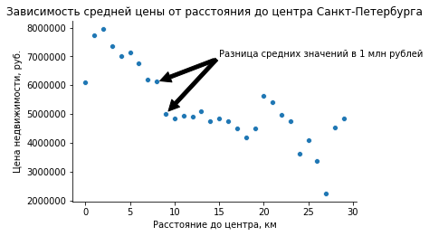

```python
sns.relplot(x=spb_center_nearest.index, y='last_price', data=spb_center_nearest, height=4, aspect=1.4)
plt.annotate('Разница средних значений в 1 млн рублей', xy=(8, 6110000), xytext=(15, 7000000),
            arrowprops=dict(facecolor='black', shrink=0.05))
plt.annotate('', xy=(9, 5000000), xytext=(15, 7000000),
            arrowprops=dict(facecolor='black', shrink=0.05))
plt.title('Зависимость средней цены от расстояния до центра Санкт-Петербурга')
plt.ylabel('Цена недвижимости, руб.')
plt.xlabel('Расстояние до центра, км')
plt.show()
```

Таким образом, будем считать центром Санкт-Петербурга окружность радиусом **8 км**.

```python
spb_center = good_data[(good_data['citycenters_km'] <= 8) & (good_data['locality_name'] == 'Санкт-Петербург')]
```

```
count    1468.000000
mean       61.269271
std        19.962747
min        12.000000
25%        45.075000
50%        59.600000
75%        75.000000
max       114.200000
Name: total_area, dtype: float64
```

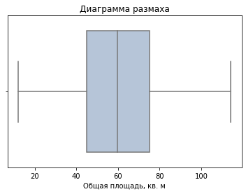

```python
print(spb_center['total_area'].describe())
sns.boxplot(spb_center['total_area'], color='lightsteelblue')
plt.title('Диаграмма размаха')
plt.xlabel('Общая площадь, кв. м')
plt.show()
```

```
count    1.468000e+03
mean     7.064107e+06
std      2.171197e+06
min      2.250000e+06
25%      5.400000e+06
50%      6.850000e+06
75%      8.600750e+06
max      1.186686e+07
Name: last_price, dtype: float64
```

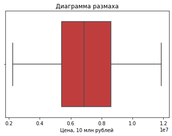

```python
print(spb_center['last_price'].describe())
sns.boxplot(spb_center['last_price'], color='tab:red')
plt.title('Диаграмма размаха')
plt.xlabel('Цена, 10 млн рублей')
plt.show()
```

```
count    1468.000000
mean        2.160082
std         0.923591
min         0.000000
25%         1.000000
50%         2.000000
75%         3.000000
max         6.000000
Name: rooms, dtype: float64
```

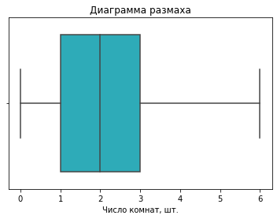

```python
print(spb_center['rooms'].describe())
sns.boxplot(spb_center['rooms'], color='tab:cyan')
plt.title('Диаграмма размаха')
plt.xlabel('Число комнат, шт.')
plt.show()
```

```
count    1468.000000
mean        2.762037
std         0.186336
min         2.400000
25%         2.550000
50%         2.750000
75%         3.000000
max         3.050000
Name: ceiling_height, dtype: float64
```

[figure not shown]

```python
print(spb_center['ceiling_height'].describe())
sns.boxplot(spb_center['ceiling_height'], color='tab:purple')
plt.title('Диаграмма размаха')
plt.xlabel('Цена, 10 млн рублей')
plt.show()
```

```
count    1468.000000
mean      137.841962
std        96.128448
min        30.000000
25%        66.750000
50%        95.000000
75%       183.000000
max       426.000000
Name: days_exposition, dtype: float64
```

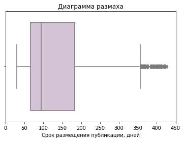

```python
print(spb_center['days_exposition'].describe())
sns.boxplot(spb_center['days_exposition'], color='thistle')
plt.title('Диаграмма размаха')
plt.xlabel('Срок размещения публикации, дней')
plt.xlim(0, 450)
plt.show()
```

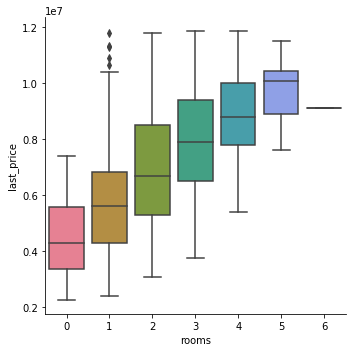

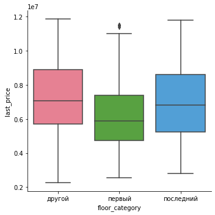

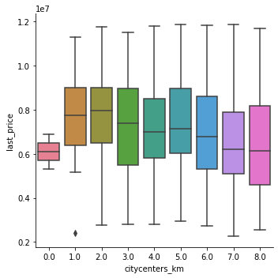

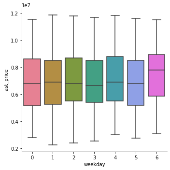

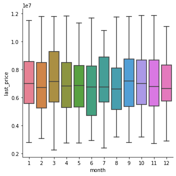

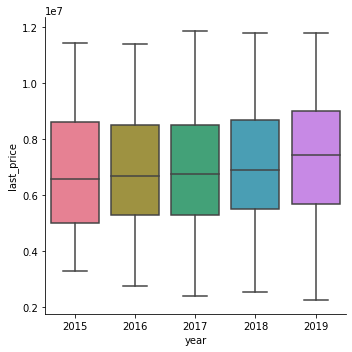

```python
for column in ['rooms', 'floor_category', 'citycenters_km', 'weekday', 'month', 'year']:
    sns.catplot(x=column, y="last_price", kind="box", data=spb_center, palette='husl')
```

### Шаг 5. Общий вывод

Для определения рыночной стоимости объектов недвижимости важны следующие параметры:

- общая площадь квартиры (аномальные значения: более 114,25 кв. м)
- расстояние до центра города (центр города огранчен окружностью радиусом 8 км)
- число комнат и этаж квартиры (чем ближе к центру, тем эти факторы весомее)
- срок продажи квартиры (слишком быстрая продажа — до 1 месяца (особенно аномальные сроки меньше 2-х недель), слишком долгая продажа — более 14 месяцев (428 дней)).
- кроме того, необходимо ввести ограничения на ввод данных о высоте потолков: допущено множество ручных ошибок (27 м вместо 2,7 м, потолки менее 2 м и т.д.).